# Whistlepodu

### Social Media Analytics End Term Project

### Topic:- Whistlepodu Twitter Analysis

### Introduction:-

#### Indian Premier League is one of the popular cricket event in the world. Many Star Players, Retired Players, Youngsters play this event to showcase their talent. The Dataset which i am working is about the Tweets of Chennai Super Kings . "#Whistlepodu" . It consists of tweets right from the beginning of the IPL Season this year 2019. Timeline Includes March 20 th 2019 to May 14 th 2019. It consists of all the information like datetime,Username,ID,tweet/text etc.Around 38568 tweets are present in between the above mentioned timeline. So, lets get deeper into the Analysis..

```python
%cd C:\Users\nsidd\OneDrive\Desktop\Python Datasets
```

```
C:\Users\nsidd\OneDrive\Desktop\Python Datasets
```

```python
%pwd
```

```
'C:\\Users\\nsidd\\OneDrive\\Desktop\\Python Datasets'
```

```python
import pandas as pd
```

```python
df=pd.read_csv("Whistlepodu.csv",sep=",")
```

```python
df.head()
```

|  | ID | datetime | has_media | is_reply | is_retweet | medias | nbr_favorite | nbr_reply | nbr_retweet | text | url | user_id | usernameTweet |
| --- | --- | --- | --- | --- | --- | --- | --- | --- | --- | --- | --- | --- | --- |
| 0 | 1108169034552377344 | 2019-03-20 06:21:01 | NaN | True | False | NaN | 1 | 0 | 0 | Winter is coming!! So better to with Thala. #Y... | /abhi_gadia/status/1108169034552377344 | 3187992722 | abhi_gadia |
| 1 | 1108172038005391360 | 2019-03-20 06:32:57 | NaN | False | False | NaN | 1 | 1 | 0 | he is coming.... \n#WhistlePodu ... https://... | /ashutosh2369/status/1108172038005391360 | 4881170673 | ashutosh2369 |
| 2 | 1108173946786992128 | 2019-03-20 06:40:32 | NaN | False | False | NaN | 0 | 0 | 0 | @ DJBravo47 is all set for getting married ... | /vatsan_18/status/1108173946786992128 | 2649867860 | vatsan_18 |
| 3 | 1108176621528207360 | 2019-03-20 06:51:10 | NaN | False | False | NaN | 739 | 2 | 137 | March 23rd Will be Long Wait For CSK Fans..! J... | /kettavan_Memes/status/1108176621528207360 | 897056528015818752 | kettavan_Memes |
| 4 | 1108177502181089280 | 2019-03-20 06:54:40 | NaN | False | False | NaN | 1 | 0 | 0 | # ChennaiSuperKings Match Schedule... @Chen... | /itsmr_chowdhary/status/1108177502181089280 | 946558538435801088 | itsmr_chowdhary |

```python
df.info() # In the given dataset, there are datatypes like boolean,integers,object
```

```
<class 'pandas.core.frame.DataFrame'>
RangeIndex: 38568 entries, 0 to 38567
Data columns (total 13 columns):
ID               38568 non-null int64
datetime         38568 non-null object
has_media        2704 non-null object
is_reply         38568 non-null bool
is_retweet       38568 non-null bool
medias           2704 non-null object
nbr_favorite     38568 non-null int64
nbr_reply        38568 non-null int64
nbr_retweet      38568 non-null int64
text             38568 non-null object
url              38568 non-null object
user_id          38568 non-null int64
usernameTweet    38568 non-null object
dtypes: bool(2), int64(5), object(6)
memory usage: 3.3+ MB
```

```python
tweets=df
tweets.info()
```

```
<class 'pandas.core.frame.DataFrame'>
RangeIndex: 38568 entries, 0 to 38567
Data columns (total 13 columns):
ID               38568 non-null int64
datetime         38568 non-null object
has_media        2704 non-null object
is_reply         38568 non-null bool
is_retweet       38568 non-null bool
medias           2704 non-null object
nbr_favorite     38568 non-null int64
nbr_reply        38568 non-null int64
nbr_retweet      38568 non-null int64
text             38568 non-null object
url              38568 non-null object
user_id          38568 non-null int64
usernameTweet    38568 non-null object
dtypes: bool(2), int64(5), object(6)
memory usage: 3.3+ MB
```

### 1) TimeLine of DataSet

#### As the first match was held on 23-Mar-2019, the Tweets started prior to three days before the first match of the Season. This shows the fan base of CSK and one and only MSDhoni. Coming to the end of the Tweets, after the Finale between Mumbai and Chennai on May 12 2019. The fans continued to tweet to show their love and support.

```python
df['datetime'].min() # start of the Tweets
```

```
'2019-03-20 06:21:01'
```

```python
df['datetime'].max()  # end of the Tweets
```

```
'2019-05-14 05:08:16'
```

### 2) Number of tweets in Dataset

```python
len(tweets['text']) #Len function provides the number of tweets in the dataset
```

```
38568
```

```python
tweets.isnull().sum()   #missing values are present in has_media & medias, so we can drop this column
```

```
ID                   0
datetime             0
has_media        35864
is_reply             0
is_retweet           0
medias           35864
nbr_favorite         0
nbr_reply            0
nbr_retweet          0
text                 0
url                  0
user_id              0
usernameTweet        0
dtype: int64
```

```python
tweets['text'].head()
```

```
0    Winter is coming!! So better to with Thala. #Y...
1    he is coming.... \n#WhistlePodu  ...  https://...
2    @ DJBravo47  is all set for getting married   ...
3    March 23rd Will be Long Wait For CSK Fans..! J...
4    # ChennaiSuperKings  Match Schedule...   @Chen...
Name: text, dtype: object
```

### Code used to Scrape the Twitter Data

```python
#####
import json
import glob
import os

SAVE_TWEET_PATH = 'C:/Users/nsidd/Downloads/TweetScraper-master/Data/tweet/'
SAVE_USER_PATH = './Data/user/'
SAVE_TWEET_DB='C:/Users/nsidd/Downloads/TweetScraper-master/'
SAVE_USER_DB='./Data/'
def readTweets():
	files=glob.iglob(SAVE_TWEET_PATH+'**/*',recursive=True)
	tweets_list=[]

	for __file__ in files:

		with open(__file__,"r",encoding="utf-8") as f:
			d = json.load(f)
			tweets_list.append(d)
	return pd.DataFrame(tweets_list)
def readUsers():
	files=glob.iglob(SAVE_USER_PATH+'**/*',recursive=True)
	users_list=[]

	for __file__ in files:

		with open(__file__) as f:
			d = json.load(f)
			users_list.append(d)
	return pd.DataFrame(users_list)

def saveUsers(data):
	if not os.path.exists(SAVE_USER_DB):
		os.mkdir(SAVE_USER_DB)
	data.to_csv(SAVE_USER_DB+"Users.csv",encoding='utf-8',index=False)

def saveTweets(data):
	if not os.path.exists(SAVE_TWEET_DB):
		os.makedirs(SAVE_TWEET_DB)
	data.to_csv(SAVE_TWEET_DB+'Tweets.csv',encoding='utf-8',index=False)

if __name__ == '__main__':
	data=readTweets()
	saveTweets(data)
```

### Dropping Unnecessary Columns

```python
tweets=tweets.drop(['ID','url','user_id','has_media','medias'],axis=1) # These columns couldn't provide much info so dropping
```

```python
tweets.head()
```

|  | datetime | is_reply | is_retweet | nbr_favorite | nbr_reply | nbr_retweet | text | usernameTweet |
| --- | --- | --- | --- | --- | --- | --- | --- | --- |
| 0 | 2019-03-20 06:21:01 | True | False | 1 | 0 | 0 | Winter is coming!! So better to with Thala. #Y... | abhi_gadia |
| 1 | 2019-03-20 06:32:57 | False | False | 1 | 1 | 0 | he is coming.... \n#WhistlePodu ... https://... | ashutosh2369 |
| 2 | 2019-03-20 06:40:32 | False | False | 0 | 0 | 0 | @ DJBravo47 is all set for getting married ... | vatsan_18 |
| 3 | 2019-03-20 06:51:10 | False | False | 739 | 2 | 137 | March 23rd Will be Long Wait For CSK Fans..! J... | kettavan_Memes |
| 4 | 2019-03-20 06:54:40 | False | False | 1 | 0 | 0 | # ChennaiSuperKings Match Schedule... @Chen... | itsmr_chowdhary |

```python
import matplotlib.pyplot as plt
```

```python
tweets['len_message']=tweets['text'].apply(lambda x:len(x.split()))   #To get the length of each tweet we use lambda function
```

```python
tweets.head()
```

|  | datetime | is_reply | is_retweet | nbr_favorite | nbr_reply | nbr_retweet | text | usernameTweet | len_message |
| --- | --- | --- | --- | --- | --- | --- | --- | --- | --- |
| 0 | 2019-03-20 06:21:01 | True | False | 1 | 0 | 0 | Winter is coming!! So better to with Thala. #Y... | abhi_gadia | 10 |
| 1 | 2019-03-20 06:32:57 | False | False | 1 | 1 | 0 | he is coming.... \n#WhistlePodu ... https://... | ashutosh2369 | 9 |
| 2 | 2019-03-20 06:40:32 | False | False | 0 | 0 | 0 | @ DJBravo47 is all set for getting married ... | vatsan_18 | 14 |
| 3 | 2019-03-20 06:51:10 | False | False | 739 | 2 | 137 | March 23rd Will be Long Wait For CSK Fans..! J... | kettavan_Memes | 38 |
| 4 | 2019-03-20 06:54:40 | False | False | 1 | 0 | 0 | # ChennaiSuperKings Match Schedule... @Chen... | itsmr_chowdhary | 14 |

```python
tweets['len_message'].describe()
```

```
count    38568.000000
mean        20.448455
std         10.633027
min          1.000000
25%         12.000000
50%         19.000000
75%         27.000000
max         71.000000
Name: len_message, dtype: float64
```

```python
import matplotlib.pyplot as plt
```

```python
import seaborn as sns
```

### Distribution of Length of the Tweets

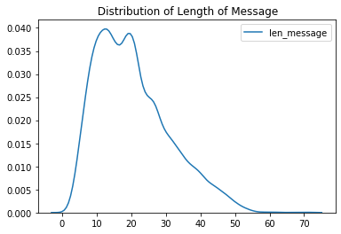

```python
sns.kdeplot(tweets['len_message']).set_title(" Distribution of Length of Message")
```

```python
tweets['is_retweet'].value_counts()
```

```
False    38568
Name: is_retweet, dtype: int64
```

```python
tweets['is_retweet']=tweets['text'].apply(lambda x:x[:2]=='RT')
tweets['is_retweet'].head()  # No of Retweets
```

```
0    False
1    False
2    False
3    False
4    False
Name: is_retweet, dtype: bool
```

```python
tweets['is_retweet'].value_counts()
```

```
False    38488
True        80
Name: is_retweet, dtype: int64
```

#### Distribution of Retweet

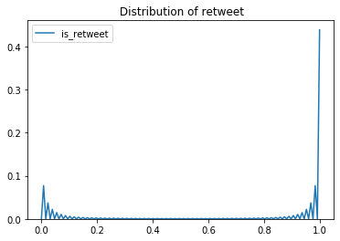

```python
sns.kdeplot(tweets['is_retweet']).set_title(" Distribution of retweet") #Graph for Distribution of retweet
```

```python
tweets.head()
```

|  | datetime | is_reply | is_retweet | nbr_favorite | nbr_reply | nbr_retweet | text | usernameTweet | len_message |
| --- | --- | --- | --- | --- | --- | --- | --- | --- | --- |
| 0 | 2019-03-20 06:21:01 | True | False | 1 | 0 | 0 | Winter is coming!! So better to with Thala. #Y... | abhi_gadia | 10 |
| 1 | 2019-03-20 06:32:57 | False | False | 1 | 1 | 0 | he is coming.... \n#WhistlePodu ... https://... | ashutosh2369 | 9 |
| 2 | 2019-03-20 06:40:32 | False | False | 0 | 0 | 0 | @ DJBravo47 is all set for getting married ... | vatsan_18 | 14 |
| 3 | 2019-03-20 06:51:10 | False | False | 739 | 2 | 137 | March 23rd Will be Long Wait For CSK Fans..! J... | kettavan_Memes | 38 |
| 4 | 2019-03-20 06:54:40 | False | False | 1 | 0 | 0 | # ChennaiSuperKings Match Schedule... @Chen... | itsmr_chowdhary | 14 |

### By using regular expressions, we can extract the hashtags and saving in a separate column

```python
import re #regular Expressions
```

```python
def find_hashtags(text):
    '''This function will extract hashtags'''
    return re.findall('(#[A-Za-z]+[A-Za-z0-9-_]+)', text)
```

```python
tweets['hashtags']=tweets.text.apply(find_hashtags)
```

```python
tweets.head()
```

|  | datetime | is_reply | is_retweet | nbr_favorite | nbr_reply | nbr_retweet | text | usernameTweet | len_message | hashtags |
| --- | --- | --- | --- | --- | --- | --- | --- | --- | --- | --- |
| 0 | 2019-03-20 06:21:01 | True | False | 1 | 0 | 0 | Winter is coming!! So better to with Thala. #Y... | abhi_gadia | 10 | [#Yellove, #WhistlePodu] |
| 1 | 2019-03-20 06:32:57 | False | False | 1 | 1 | 0 | he is coming.... \n#WhistlePodu ... https://... | ashutosh2369 | 9 | [#WhistlePodu] |
| 2 | 2019-03-20 06:40:32 | False | False | 0 | 0 | 0 | @ DJBravo47 is all set for getting married ... | vatsan_18 | 14 | [#WhistlePodu] |
| 3 | 2019-03-20 06:51:10 | False | False | 739 | 2 | 137 | March 23rd Will be Long Wait For CSK Fans..! J... | kettavan_Memes | 38 | [#CSK, #IPL2019, #WhistlePodu] |
| 4 | 2019-03-20 06:54:40 | False | False | 1 | 0 | 0 | # ChennaiSuperKings Match Schedule... @Chen... | itsmr_chowdhary | 14 | [#WhistlePodu, #Yellove, #YelloveAgain] |

```python
tweets['hashtags'].describe()
```

```
count              38568
unique             18419
top       [#WhistlePodu]
freq                1752
Name: hashtags, dtype: object
```

```python
# take the rows from the hashtag columns where there are actually hashtags
hashtags_list_df = tweets.loc[
                       tweets.hashtags.apply(
                           lambda hashtags_list: hashtags_list !=[]
                       ),['hashtags']]
```

```python
# create dataframe where each use of hashtag gets its own row
flattened_hashtags_df = pd.DataFrame(
    [hashtag for hashtags_list in hashtags_list_df.hashtags
    for hashtag in hashtags_list],
    columns=['hashtags'])
```

```python
# number of unique hashtags
flattened_hashtags_df['hashtags'].unique().size
```

```
6711
```

```python
# count of appearances of each hashtag
popular_hashtags = flattened_hashtags_df.groupby('hashtags').size()\
                                        .reset_index(name='counts')\
                                        .sort_values('counts', ascending=False)\
                                        .reset_index(drop=True)
```

```python
import numpy as np
```

### Visual Representation of Tweets

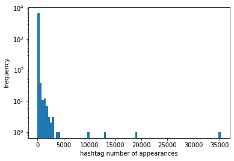

```python
# number of times each hashtag appears
counts = flattened_hashtags_df.groupby(['hashtags']).size()\
                              .reset_index(name='counts')\
                              .counts

# define bins for histogram
my_bins = np.arange(0,counts.max()+400, 400)-0.5

# plot histogram of tweet counts
plt.figure()
plt.hist(counts, bins = my_bins)
plt.xlabels = np.arange(1,counts.max()+400, 400)
plt.xlabel('hashtag number of appearances')
plt.ylabel('frequency')
plt.yscale('log', nonposy='clip')
plt.show()
```

### We have datetime in our dataset, so we can extract date,time,month using pd.to_datetime

```python
tweets['datetime']=pd.to_datetime(tweets['datetime'], errors='coerce')
```

```python
tweets['datetime'].describe()
```

```
count                   38568
unique                  36928
top       2019-04-01 00:12:48
freq                        5
first     2019-03-20 06:21:01
last      2019-05-14 05:08:16
Name: datetime, dtype: object
```

```python
tweets['year']=tweets['datetime'].dt.year
```

```python
tweets['time']=tweets['datetime'].dt.time
```

```python
tweets.head()
```

[output not shown]

```python
tweets['month']=tweets['datetime'].dt.month
```

```python
tweets['date']=tweets['datetime'].dt.date
```

```python
tweets['date']=tweets['datetime'].dt.day
```

```python
tweets['text'].head()
```

```
0    Winter is coming!! So better to with Thala. #Y...
1    he is coming.... \n#WhistlePodu  ...  https://...
2    @ DJBravo47  is all set for getting married   ...
3    March 23rd Will be Long Wait For CSK Fans..! J...
4    # ChennaiSuperKings  Match Schedule...   @Chen...
Name: text, dtype: object
```

```python
tweets.head()
```

|  | datetime | is_reply | is_retweet | nbr_favorite | nbr_reply | nbr_retweet | text | usernameTweet | len_message | hashtags | year | time | month | date |
| --- | --- | --- | --- | --- | --- | --- | --- | --- | --- | --- | --- | --- | --- | --- |
| 0 | 2019-03-20 06:21:01 | True | False | 1 | 0 | 0 | Winter is coming!! So better to with Thala. #Y... | abhi_gadia | 10 | [#Yellove, #WhistlePodu] | 2019 | 06:21:01 | 3 | 20 |
| 1 | 2019-03-20 06:32:57 | False | False | 1 | 1 | 0 | he is coming.... \n#WhistlePodu ... https://... | ashutosh2369 | 9 | [#WhistlePodu] | 2019 | 06:32:57 | 3 | 20 |
| 2 | 2019-03-20 06:40:32 | False | False | 0 | 0 | 0 | @ DJBravo47 is all set for getting married ... | vatsan_18 | 14 | [#WhistlePodu] | 2019 | 06:40:32 | 3 | 20 |
| 3 | 2019-03-20 06:51:10 | False | False | 739 | 2 | 137 | March 23rd Will be Long Wait For CSK Fans..! J... | kettavan_Memes | 38 | [#CSK, #IPL2019, #WhistlePodu] | 2019 | 06:51:10 | 3 | 20 |
| 4 | 2019-03-20 06:54:40 | False | False | 1 | 0 | 0 | # ChennaiSuperKings Match Schedule... @Chen... | itsmr_chowdhary | 14 | [#WhistlePodu, #Yellove, #YelloveAgain] | 2019 | 06:54:40 | 3 | 20 |

### Likes Distribution

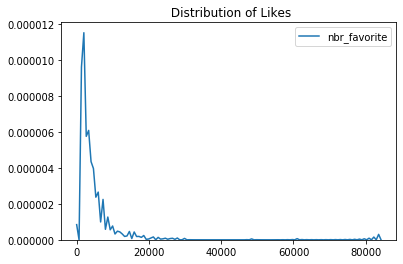

```python
# GRAPHICAL REPRESENTATION OF LIKES
sns.kdeplot(tweets['nbr_favorite']).set_title(" Distribution of Likes")
```

```python
# NOW SAVING THE DATA INTO OTHER DATAFILE CALLES "TWEETS1" FOR TEXT CLEANING
tweets1=tweets
tweets1.head(5)
```

|  | datetime | is_reply | is_retweet | nbr_favorite | nbr_reply | nbr_retweet | text | usernameTweet | len_message | hashtags | year | time | month | date |
| --- | --- | --- | --- | --- | --- | --- | --- | --- | --- | --- | --- | --- | --- | --- |
| 0 | 2019-03-20 06:21:01 | True | False | 1 | 0 | 0 | Winter is coming!! So better to with Thala. #Y... | abhi_gadia | 10 | [#Yellove, #WhistlePodu] | 2019 | 06:21:01 | 3 | 20 |
| 1 | 2019-03-20 06:32:57 | False | False | 1 | 1 | 0 | he is coming.... \n#WhistlePodu ... https://... | ashutosh2369 | 9 | [#WhistlePodu] | 2019 | 06:32:57 | 3 | 20 |
| 2 | 2019-03-20 06:40:32 | False | False | 0 | 0 | 0 | @ DJBravo47 is all set for getting married ... | vatsan_18 | 14 | [#WhistlePodu] | 2019 | 06:40:32 | 3 | 20 |
| 3 | 2019-03-20 06:51:10 | False | False | 739 | 2 | 137 | March 23rd Will be Long Wait For CSK Fans..! J... | kettavan_Memes | 38 | [#CSK, #IPL2019, #WhistlePodu] | 2019 | 06:51:10 | 3 | 20 |
| 4 | 2019-03-20 06:54:40 | False | False | 1 | 0 | 0 | # ChennaiSuperKings Match Schedule... @Chen... | itsmr_chowdhary | 14 | [#WhistlePodu, #Yellove, #YelloveAgain] | 2019 | 06:54:40 | 3 | 20 |

### Number of Tweets Based on Date

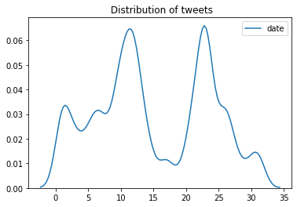

```python
# GRAPHICAL REPRESENTATION OF LIKES
sns.kdeplot(tweets['date']).set_title(" Distribution of tweets")
```

### Cleaning the Tweets

#### The Below function removes the stemmer , emojis, space,hashtags,punctuations etc

```python
# DEFING ALL THE FUNCTIONS NEEDED FOR CLEANING THE TEXT
import re # regular expressions
import string # to accept string
import nltk # it is a text processing libraries for tokenization, parsing, classification, stemming, tagging and semantic reasoning.
from nltk.corpus import stopwords # particular words which are not neccesary in english
from nltk.stem import PorterStemmer# we use stemmer to remove the "ing" of words
def clean_text(text):
    ps=PorterStemmer()
    text1 = re.sub(r'^https?:\/\/.*[\r\n]*', '', text)#remove url
    print(text1)
    text1=re.sub('[^\w\s#@/:%.,_-]', '', flags=re.UNICODE)#remove emojis
    print(text1)
    text1=re.sub("\s+"," ",x) # removing the space
    print(text1)
    text1=re.sub('#[\w]+', '', x) # removing 'hastags'
    print(text1)
    text_cleaned=" ".join([x for x in text1 if x not in string.punctuation])# remove punctuations
    print(text_cleaned)
    text_cleaned=text_cleaned.lower() #converting all words upper cases into lower case
    print(text_cleaned)
    text_cleaned=text_cleaned.split(" ")# splitting the words with space if neccessary
    print(text_cleaned)
    text_tokens=[token for token in text_cleaned if token not in STOPWORDS] # Prints list of all tokens in the document
    stem_words=[ps.stem(stem) for stem in text_tokens ] # the stem of all tokens in the document
    text=" ".join(stem_words)
    text_cleaned=re.sub(' +',' ',text)# for removing the extra space
    return text_cleaned
```

### To remove the Url we use the below syntax for a clean tweet

```python
tweets1['cleaned_text']=tweets1['text'].apply(lambda x:re.sub('http.*','',x)) # removing the URL
tweets1['cleaned_text']=tweets1['cleaned_text'].apply(lambda x:re.sub("\s+"," ",x))# removing the space
tweets1['cleaned_text'].head(5)
```

```
0    Winter is coming!! So better to with Thala. #Y...
1                   he is coming.... #WhistlePodu ...
2    @ DJBravo47 is all set for getting married #Wh...
3    March 23rd Will be Long Wait For CSK Fans..! J...
4    # ChennaiSuperKings Match Schedule... @Chennai...
Name: cleaned_text, dtype: object
```

```python
tweets1['cleaned_text'] = tweets1['cleaned_text'].str.replace('[^\w\s#@/:%.,_-]', '', flags=re.UNICODE) ## removing emojis
tweets1['cleaned_text'] = tweets1['cleaned_text'].apply(lambda x:re.sub('#[\w]+', '', x)) # removing '#'
tweets1['cleaned_text'] = tweets1['cleaned_text'].apply(lambda x:re.sub("\s+"," ",x))# removing the space
tweets1['cleaned_text'].head(5)
```

```
0           Winter is coming So better to with Thala.
1                                he is coming.... ...
2    @ DJBravo47 is all set for getting married @Ch...
3    March 23rd Will be Long Wait For CSK Fans.. Ju...
4    # ChennaiSuperKings Match Schedule... @Chennai...
Name: cleaned_text, dtype: object
```

```python
tweets1['cleaned_text'].tolist() # to check the reviews
```

[output not shown]

[output cut: 946 more lines]

[output not shown]

#### StopWords are not necessary because it does'nt make any sense. below is a list of all stopwords.

```python
STOPWORDS=stopwords.words('english')
print(STOPWORDS)
```

[output not shown]

```python
tweets1['cleaned_text']=tweets1['cleaned_text'].apply(lambda cleaned_text:"".join([x for x in cleaned_text if x not in string.punctuation]))
# removing punctuations
tweets1['cleaned_text']=tweets1['cleaned_text'].apply(lambda x:x.lower()) # CONVERTING THE UPPERCASE LETTERS TO LOWERCASE
tweets1['cleaned_text'].head(5)
```

```
0            winter is coming so better to with thala
1                                       he is coming
2     djbravo47 is all set for getting married chen...
3    march 23rd will be long wait for csk fans just...
4     chennaisuperkings match schedule chennaiipl m...
Name: cleaned_text, dtype: object
```

```python
tweets1.head(5) # finally checking the cleaned data
```

|  | datetime | is_reply | is_retweet | nbr_favorite | nbr_reply | nbr_retweet | text | usernameTweet | len_message | hashtags | year | time | month | date | cleaned_text |
| --- | --- | --- | --- | --- | --- | --- | --- | --- | --- | --- | --- | --- | --- | --- | --- |
| 0 | 2019-03-20 06:21:01 | True | False | 1 | 0 | 0 | Winter is coming!! So better to with Thala. #Y... | abhi_gadia | 10 | [#Yellove, #WhistlePodu] | 2019 | 06:21:01 | 3 | 20 | winter is coming so better to with thala |
| 1 | 2019-03-20 06:32:57 | False | False | 1 | 1 | 0 | he is coming.... \n#WhistlePodu ... https://... | ashutosh2369 | 9 | [#WhistlePodu] | 2019 | 06:32:57 | 3 | 20 | he is coming |
| 2 | 2019-03-20 06:40:32 | False | False | 0 | 0 | 0 | @ DJBravo47 is all set for getting married ... | vatsan_18 | 14 | [#WhistlePodu] | 2019 | 06:40:32 | 3 | 20 | djbravo47 is all set for getting married chen... |
| 3 | 2019-03-20 06:51:10 | False | False | 739 | 2 | 137 | March 23rd Will be Long Wait For CSK Fans..! J... | kettavan_Memes | 38 | [#CSK, #IPL2019, #WhistlePodu] | 2019 | 06:51:10 | 3 | 20 | march 23rd will be long wait for csk fans just... |
| 4 | 2019-03-20 06:54:40 | False | False | 1 | 0 | 0 | # ChennaiSuperKings Match Schedule... @Chen... | itsmr_chowdhary | 14 | [#WhistlePodu, #Yellove, #YelloveAgain] | 2019 | 06:54:40 | 3 | 20 | chennaisuperkings match schedule chennaiipl m... |

```python
!pip install gensim
#Gensim is a Python library for topic modelling, document indexing and similarity retrieval with large corpora.
```

#### Unigrams,Bigrams,Trigrams

```python
from nltk.tokenize import RegexpTokenizer
from nltk.corpus import stopwords
from nltk.stem.snowball import SnowballStemmer
#from gensim import corpora, models
#import gensim
import nltk
##nltk.download("stopwords")


%autoreload 2

# Visualizations
import plotly.express as px

import matplotlib.pyplot as plt
import seaborn as sns
import re


import gensim
from gensim import corpora

# libraries for visualization
import pyLDAvis
import pyLDAvis.gensim
```

```
UsageError: Line magic function `%autoreload` not found.
```

```python
tokenizer = RegexpTokenizer(r'\w+') # it converts python text strings into streams of token objects
```

```python
data1 = tweets1.cleaned_text[0]
```

```python
tokens = tokenizer.tokenize(data1.lower())
```

```python
print('{} characters in string vs {} words in a list'.format(len(data1),                                                             len(tokens)))
print(tokens[:10])
```

```
41 characters in string vs 8 words in a list
['winter', 'is', 'coming', 'so', 'better', 'to', 'with', 'thala']
```

```python
nltk_stpwd = stopwords.words('english') # identifying the stopwords in english
print(len(set(nltk_stpwd)))
print(nltk_stpwd[:10])
```

```
179
['i', 'me', 'my', 'myself', 'we', 'our', 'ours', 'ourselves', 'you', "you're"]
```

```python
stopped_tokens = [token for token in tokens if not token in nltk_stpwd] # which are not stopwords
print(stopped_tokens[:10])
```

```
['winter', 'coming', 'better', 'thala']
```

```python
sb_stemmer = SnowballStemmer('english')#Stemming is the process of producing morphological variants of a root/base word.
```

```python
stemmed_tokens = [sb_stemmer.stem(token) for token in stopped_tokens]
print(stemmed_tokens)
```

```
['winter', 'come', 'better', 'thala']
```

```python
num_reviews = tweets1.shape[0]
doc_set = [tweets1.cleaned_text[i] for i in range(num_reviews)]
```

```python
texts = []
```

```python
for doc in doc_set:
    tokens = tokenizer.tokenize(doc.lower())
    stopped_tokens = [token for token in tokens if not token in nltk_stpwd]
    stemmed_tokens = [sb_stemmer.stem(token) for token in stopped_tokens]
    texts.append(stemmed_tokens)

print(texts[1])
```

```
['come']
```

```python
import gensim #Gensim is a Python library for topic modelling, document indexing and similarity retrieval with large corpora.
from gensim import corpora
#*Corpora* is a lightweight, fast and scalable corpus library
# it is able to store a collection of raw text documents with additional key-value headers
```

```python
texts_dict = corpora.Dictionary(texts)
texts_dict.save('cleaned.dict') #elec_review
print(texts_dict)  #### Create a dictionary using corpora
```

```
Dictionary(32909 unique tokens: ['better', 'come', 'thala', 'winter', 'chennaiipl']...)
```

```python
import operator
print("IDs 1 through 10: {}".format(sorted(texts_dict.token2id.items(), key=operator.itemgetter(1), reverse = False)[:10]))
```

```
IDs 1 through 10: [('better', 0), ('come', 1), ('thala', 2), ('winter', 3), ('chennaiipl', 4), ('djbravo47', 5), ('get', 6), ('marri', 7), ('set', 8), ('23rd', 9)]
```

```python
print(tweets1.cleaned_text.str.contains("agree").value_counts())
```

```
False    38499
True        69
Name: cleaned_text, dtype: int64
```

```python
texts_dict.filter_extremes(no_below=30, no_above=0.15) # inplace filter
print(texts_dict)
print("top terms:")
print(sorted(texts_dict.token2id.items(), key=operator.itemgetter(1), reverse = False)[:10])
```

```
Dictionary(1384 unique tokens: ['better', 'come', 'thala', 'djbravo47', 'get']...)
top terms:
[('better', 0), ('come', 1), ('thala', 2), ('djbravo47', 3), ('get', 4), ('set', 5), ('3', 6), ('csk', 7), ('day', 8), ('den', 9)]
```

```python
corpus = [texts_dict.doc2bow(text) for text in texts]
len(corpus)
```

```
38568
```

```python
from collections import Counter
```

### Importing Vader For Sentiment Analysis

```python
from vaderSentiment.vaderSentiment import SentimentIntensityAnalyzer
analyser = SentimentIntensityAnalyzer()
```

```python
def sentiment_analyzer_scores(sentence):
    score = analyser.polarity_scores(sentence)
    #print(score)
    return score
```

```python
def compound_score(text):
    sc=sentiment_analyzer_scores(text)
    return sc['compound']
```

```python
tweets1['comp_score']=tweets1['cleaned_text'].apply(lambda x:compound_score(x))
```

```python
tweets1.head(5)
```

|  | datetime | is_reply | is_retweet | nbr_favorite | nbr_reply | nbr_retweet | text | usernameTweet | len_message | hashtags | year | time | month | date | cleaned_text | comp_score |
| --- | --- | --- | --- | --- | --- | --- | --- | --- | --- | --- | --- | --- | --- | --- | --- | --- |
| 0 | 2019-03-20 06:21:01 | True | False | 1 | 0 | 0 | Winter is coming!! So better to with Thala. #Y... | abhi_gadia | 10 | [#Yellove, #WhistlePodu] | 2019 | 06:21:01 | 3 | 20 | winter is coming so better to with thala | 0.5777 |
| 1 | 2019-03-20 06:32:57 | False | False | 1 | 1 | 0 | he is coming.... \n#WhistlePodu ... https://... | ashutosh2369 | 9 | [#WhistlePodu] | 2019 | 06:32:57 | 3 | 20 | he is coming | 0.0000 |
| 2 | 2019-03-20 06:40:32 | False | False | 0 | 0 | 0 | @ DJBravo47 is all set for getting married ... | vatsan_18 | 14 | [#WhistlePodu] | 2019 | 06:40:32 | 3 | 20 | djbravo47 is all set for getting married chen... | 0.0000 |
| 3 | 2019-03-20 06:51:10 | False | False | 739 | 2 | 137 | March 23rd Will be Long Wait For CSK Fans..! J... | kettavan_Memes | 38 | [#CSK, #IPL2019, #WhistlePodu] | 2019 | 06:51:10 | 3 | 20 | march 23rd will be long wait for csk fans just... | 0.2732 |
| 4 | 2019-03-20 06:54:40 | False | False | 1 | 0 | 0 | # ChennaiSuperKings Match Schedule... @Chen... | itsmr_chowdhary | 14 | [#WhistlePodu, #Yellove, #YelloveAgain] | 2019 | 06:54:40 | 3 | 20 | chennaisuperkings match schedule chennaiipl m... | 0.0000 |

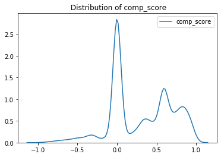

```python
# GRAPHICAL REPRESENTATION OF comp_score
sns.kdeplot(tweets['comp_score']).set_title(" Distribution of comp_score")
```

```python
def emotion(score):
    if score>0.5:
        return "positive"
    if score<0.5:
        return "negative"
    if score==0.5:
        return "neutral"
```

### Based on the Score the emotions are seggregated like Positive,negative,neutral

```python
tweets1['sentiment']=tweets1['comp_score'].apply(lambda x:emotion(x))# storing it into a new column called sentiment
tweets1.sample(5)
```

|  | datetime | is_reply | is_retweet | nbr_favorite | nbr_reply | nbr_retweet | text | usernameTweet | len_message | hashtags | year | time | month | date | cleaned_text | comp_score | sentiment |
| --- | --- | --- | --- | --- | --- | --- | --- | --- | --- | --- | --- | --- | --- | --- | --- | --- | --- |
| 36956 | 2019-05-12 22:47:48 | False | False | 0 | 0 | 0 | What Dhoni run-out? #Yellove #WhistlePodu #I... | yeshwantmiranda | 8 | [#Yellove, #WhistlePodu, #IPL2019Final, #MIvCSK] | 2019 | 22:47:48 | 5 | 12 | what dhoni runout | 0.0000 | negative |
| 23890 | 2019-04-23 23:12:32 | False | False | 1 | 0 | 0 | That was a good contest between Watto and Rash... | srivatsa224 | 11 | [#CSKvSRH, #WhistlePodu] | 2019 | 23:12:32 | 4 | 23 | that was a good contest between watto and rashid | 0.4404 | negative |
| 13251 | 2019-04-06 20:18:20 | False | False | 0 | 0 | 0 | # KLRahul was very lucky when the bails didn'... | Not_A_Shammer | 28 | [#MSDhoni, #CSKvsKXIP, #ChennaiSuperKings, #CS... | 2019 | 20:18:20 | 4 | 6 | klrahul was very lucky when the bails didnt f... | 0.4754 | negative |
| 36034 | 2019-05-12 19:52:59 | False | False | 0 | 0 | 0 | IPL - Indian Premier League 2019 - FINAL \n\nC... | IMJineshUdani | 32 | [#CSK, #Yellove, #WhistlePodu] | 2019 | 19:52:59 | 5 | 12 | ipl indian premier league 2019 final come on... | 0.5994 | positive |
| 12301 | 2019-04-06 00:29:54 | False | False | 1 | 0 | 0 | MSD storm in Chennai with Raina 36(32) and bra... | arnav_nagayech | 44 | [#VIVOIPL, #IPL2019, #CSKvsRR, #Yellove, #Whis... | 2019 | 00:29:54 | 4 | 6 | msd storm in chennai with raina 3632 and bravo... | 0.6705 | positive |

```python
tweets1['sentiment'].value_counts()
```

```
negative    23044
positive    15523
neutral     1
Name: sentiment, dtype: int64
```

#### From the above syntax we can see that around 23044 tweets are negative and 15523 tweets are positive having one tweet as neutral

```python
tweets1['sentiment'].describe()
```

```
count        38568
unique           3
top       negative
freq         23044
Name: sentiment, dtype: object
```

### Distribution of Tweet Sentiments

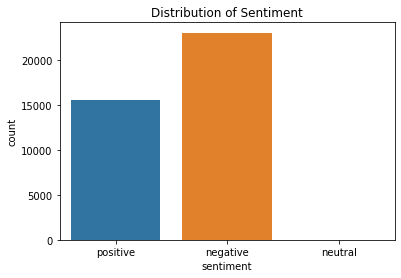

```python
sns.countplot(tweets1['sentiment']).set_title("Distribution of Sentiment")
```

```python
from collections import Counter
```

```python
positive_tweets=tweets1.loc[tweets1['sentiment']=='positive','cleaned_text'].tolist()# storing in a new name
positive_tweets[0:5]
```

```
['winter is coming so better to with thala ',
 'chennai super kings ',
 'ms dhoni with his sweetheart pictwittercomtjuny7tsya',
 'achennai super kings ',
 ' roarofthelion msdhoni saakshisrawat imjadeja imraina chennaiipl dhoniism cricprabhu ipl hotstarhelps love u my captain cool check out what did we do wrong on hotstar ']
```

```python
negative_tweets=tweets1.loc[tweets1['sentiment']=='negative','cleaned_text'].tolist()
negative_tweets[0:5]
```

```
['he is coming  ',
 ' djbravo47 is all set for getting married chennaiipl ',
 'march 23rd will be long wait for csk fans just 3 days to go for it win or lose is a secondary seeing the lions at the den is the first one pictwittercomhxi3m3zopt',
 ' chennaisuperkings match schedule chennaiipl msdhoni ipl bcci bccidomestic icc pictwittercomw9a7i44ycx',
 'any guess who is this getting married chennaiipl new delhi ']
```

```python
neutral_tweets=tweets1.loc[tweets1['sentiment']=='neutral','cleaned_text'].tolist()
neutral_tweets[0:5]
```

```
['this hurts more than d yesterday loss what a man of dedication atleast we should have won yesterday for this man get well soon champ shanerwatson33 pictwittercomu2qhxe4zmu']
```

```python
#### Below Function splits positive and negative tweets
```

```python
def getMostCommon(cleaned_text,topn=20):
    text_cleaned=" ".join(cleaned_text)
    tokenised_tweets=text_cleaned.split(" ")
    freq_counter=Counter(tokenised_tweets)
    return freq_counter.most_common(topn)
```